# Практична робота 4

# Тема. Алгоритми пошуку та їх складність

# Мета: опанувати основні алгоритми сортування та навчитись методам аналізу їх асимптотичної складності.

# 1. Оцінка асимптотичну складність алгоритму лінійного пошуку у 𝑂-нотації в найгіршому і в найкращому випадку

Найгірший випадок: O(n) - елемент знаходиться в кінці списку або його немає. Найкращий випадок: O(1) - елемент знаходиться на першій позиції.

Покращення: Використання стражника (додає елемент у кінець списку, що зменшує кількість перевірок). Використання паралельного пошуку. Використання індексних структур (наприклад, хеш-таблиць).

# 2. Оцінка асимптотичну складність алгоритму бінарного пошуку у 𝑂-нотації в найгіршому і в найкращому випадку.

Найгірший випадок: O(log n) - список ділиться навпіл на кожній ітерації. Найкращий випадок: O(1) - шуканий елемент знаходиться в середині.

# 3.Будування алгоритм тернарного пошуку і оцінити його асимптотичну складність алгоритму у 𝑂-нотації в найгіршому і в найкращому випадку. Який з алгоритмів є оптимальнішим: бінарний, чи тернарний?

```python
def ternary_search(arr, left, right, key):
    if left > right:
        return -1  # Елемент не знайдено

    # Знаходимо дві межі розділення
    mid1 = left + (right - left) // 3
    mid2 = right - (right - left) // 3

    if arr[mid1] == key:
        return mid1
    if arr[mid2] == key:
        return mid2

    if key < arr[mid1]:
        return ternary_search(arr, left, mid1 - 1, key)  # Ліва частина
    elif key > arr[mid2]:
        return ternary_search(arr, mid2 + 1, right, key)  # Права частина
    else:
        return ternary_search(arr, mid1 + 1, mid2 - 1, key)  # Середня частина
```

Асимптотична складність у 𝑂-нотації Найгірший випадок: $$O(\log_3(n))$$. Найкращий випадок: Якщо елемент знайдено на першій ітерації, складність буде $$O(1)$$

Бінарний пошук проти тернарного Бінарний пошук розбиває масив на дві частини і має асимптотичну складність $$O(\log_2(n))$$ Тернарний пошук ділить масив на три частини з $$O(\log_3(n))$$

Логарифм зі основою 3 збільшує кількість ітерацій, але константи часу в тернарному пошуку більші. Бінарний пошук є простішим у реалізації, ефективним і використовується значно частіше.

# 4.Порівнюємо ефективність алгоритмів лінійного, бінарного та тернарного пошуку для різних розмірів вхідного списку.

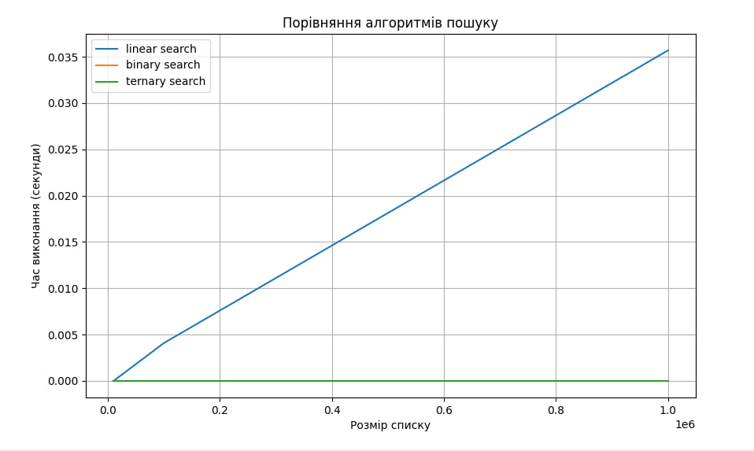

Лінійний пошук: Час зростає лінійно ($$O(n)$$). Бінарний пошук: Час зростає логарифмічно ($$O(\log_2(n)$$). Тернарний пошук: Також логарифмічно, але з більшою константою ($$O(\log_3(n)$$).

# 5.Порівнюємо алгоритми пошуку за їхньою здатністю працювати з відсортованими та не відсортованими списками.

Лінійний пошук: Працює як із відсортованими, так і з невідсортованими списками. Не використовує жодних особливостей відсортованості — перевіряє кожен елемент. Відсутність відсортованості не впливає на час виконання.

Бінарний пошук: Ефективний тільки для відсортованих списків, оскільки він використовує упорядкованість даних для поділу списку на половини. На невідсортованих списках не працює. Відсортованість значно зменшує час виконання, переходячи від $$O(n)$$ до $$O(\log n)$$

Тернарний пошук: Як і бінарний пошук, залежить від відсортованості списків. Для відсортованих списків швидший, ніж лінійний, але має додаткові витрати порівнянь. Відсутність відсортованості робить його непрацездатним.

# 6.Розглядаємо сценарії використання кожного з алгоритмів пошуку у практичних задачах і обґрунтувати вибір кожного алгоритму в конкретному випадку.

Лінійний пошук Сценарії використання: Малі набори даних. Наприклад, пошук у короткому списку контактів, де накладні витрати на складний алгоритм не виправдані. Невідсортовані дані. Коли дані не впорядковані, лінійний пошук залишається єдиним варіантом. Задачі з одноразовим доступом. Наприклад, перевірка, чи містить список певний елемент (без необхідності зберігати впорядкованість даних).

Бінарний пошук Сценарії використання: Відсортовані дані. Наприклад, пошук товарів у відсортованому каталозі за ціною. Великі обсяги даних. Ефективний для пошуку в базах даних, коли обсяг записів великий. Частий пошук. Наприклад, у додатках автозаповнення, які часто шукають у словнику слів.

Тернарний пошук Сценарії використання: Відсортовані дані. Наприклад, для точкових пошуків у специфічних задачах оптимізації. Теоретичні дослідження. Тернарний пошук може бути корисним у дослідженнях ефективності пошуку.

## 7.Висновок:

Я опанував основні алгоритми сортування та навчитись методам аналізу їх асимптотичної складності.

## 8.Відповіді на контрольні питання

1. Алгоритм пошуку — це метод знаходження певного елемента в структурі даних (масиві, списку, дереві, базі даних тощо). Він є критично важливим у комп'ютерних науках, оскільки багато задач, таких як обробка запитів, робота з базами даних, алгоритми штучного інтелекту та оптимізаційні задачі, потребують ефективного пошуку.
2. Основні критерії оцінки включають: Часова складність (кількість операцій у найгіршому, найкращому та середньому випадку). Просторова складність (кількість додаткової пам’яті, що використовується). Стійкість до змін у даних (чи потребує алгоритм попереднього сортування). Середня швидкодія на практиці (залежить від реалізації та апаратного забезпечення).
3. Лінійний пошук — це найпростіший алгоритм, який послідовно переглядає елементи масиву від початку до кінця, поки не знайде потрібний або не перебере весь список. Часова складність: Найгірший випадок: O(n) Найкращий випадок: O(1) Використовується для невідсортованих даних або малих масивів.
4. Дані повинні бути відсортовані у порядку зростання або спадання. Доступ до даних повинен бути можливий за індексом (наприклад, у масиві, а не у зв’язному списку). Масив не повинен змінюватися після сортування, оскільки зміни можуть порушити порядок і зробити бінарний пошук неефективним.
5. Переваги: Швидший за лінійний пошук $$(O(log n)$$ замість $$O(n))$$ Ефективний для великих структур даних. Працює стабільно та передбачувано. Недоліки: Потребує попереднього сортування $$(O(n log n))$$ Погано працює для динамічно змінюваних структур даних. Не підходить для неіндексованих структур (наприклад, зв’язних списків).
6. Тернарний пошук — це варіація бінарного пошуку, де замість поділу масиву на 2 частини він ділиться на 3 частини. Дві точки порівняння визначають три області, у яких може знаходитись шуканий елемент.

Часова складність: $$O(log_3 n)$$ (гірша за $$O(log_2 n))$$

Відмінність: Виконує більше порівнянь, ніж бінарний пошук, тому часто менш ефективний на практиці.

Застосування: Використовується у специфічних сценаріях, таких як оптимізаційні задачі в математичному аналізі.